# Pilot Experiment 1: Learnability

## Needed functions

Create dataframes for compehension tests and write-in data.

```r
analyze<- function(datas) {
  dataTesting <-list()
  scores <- c()
  for (i in 1:length(datas)) {
    dataTesting[[i]] <- datas[[i]][datas[[i]]$trialType == "testing",]
    dataTesting[[i]]$correct = dataTesting[[i]]$correctChoiceNumber == dataTesting[[i]]$participantChoiceNumber
  }
  return(dataTesting)
}

analyzeMeanTesting <- function(dataTesting) {
  dataTestingLevel <- list()
  for (i in 1:length(dataTesting)) {
    dataTestingLevel[[i]] <- dataTesting[[i]] %>%
      group_by(level)  %>%
      summarize(level_score = sum(correct)/length(correct))
    dataTestingLevel[[i]]$condition <- rep(dataTesting[[i]]$condition[1], 3)
    dataTestingLevel[[i]]$conditionCE <- rep(dataTesting[[i]]$conditionCE[1], 3)
    dataTestingLevel[[i]]$conditionHeadN <- rep(dataTesting[[i]]$conditionHeadN[1], 3)
    dataTestingLevel[[i]]$user <- rep(dataTesting[[i]]$workerId[1], 3)
  }
  dataTestingLevelAllUsers <- rbind()
  for (dat in dataTestingLevel) {
    dataTestingLevelAllUsers <- rbind(dataTestingLevelAllUsers, dat)
  }
  return(dataTestingLevelAllUsers)
}


analyzeWritingMeans<- function (data_write) {
  data_write_level <- list()
  for (j in 1:length(data_write)) {
    data_write_level[[j]] <- data_write[[j]] %>% group_by(level) %>% summarize(meanC = mean(correctness))
    data_write_level[[j]]$condition <- rep(data_write[[j]]$condition[1], 4)
    data_write_level[[j]]$conditionCE <- rep(data_write[[j]]$conditionCE[1], 4)
    data_write_level[[j]]$conditionHeadN <- rep(data_write[[j]]$conditionHeadN[1], 4)
    data_write_level[[j]]$user<- rep(data_write[[j]]$workerId[1], 4)
  }

  data_write_levelAll <- rbind()
  for (d in data_write_level) {
    data_write_levelAll <- rbind(data_write_levelAll, d)
  }
  return (data_write_levelAll)
}
```

## Processing the data

Import task data and demographic files, which have been anonymized.

```r
dataAnon <- read.csv('/Users/emilydavis/Desktop/iterated/artificial language/pilotLrn1/allDataAnonPilotLrn1.csv')
dataAnon$conditionCE[dataAnon$conditionCE == "no center-embedding"] <- "branching"
dataFiles <- split(dataAnon, dataAnon$workerId)
allDataWriteMerged <- dataAnon[dataAnon$trialType == "write",]
allDataTesting <- analyze(dataFiles)
allDataTestingMerged <- rbind()
for (dat in allDataTesting) {
  allDataTestingMerged <- rbind(allDataTestingMerged, dat)
}
allDataTestingLevel <- analyzeMeanTesting(allDataTesting)
allDataTestingMean <- allDataTestingLevel %>% group_by(conditionCE, conditionHeadN, level) %>% summarize(level_score = mean(level_score))
prepList <- read.csv('/Users/emilydavis/Desktop/iterated/artificial language/pilotLrn1/timeListPilotLrn1.csv')
```

## Comprehension

Graph of comprehension task.

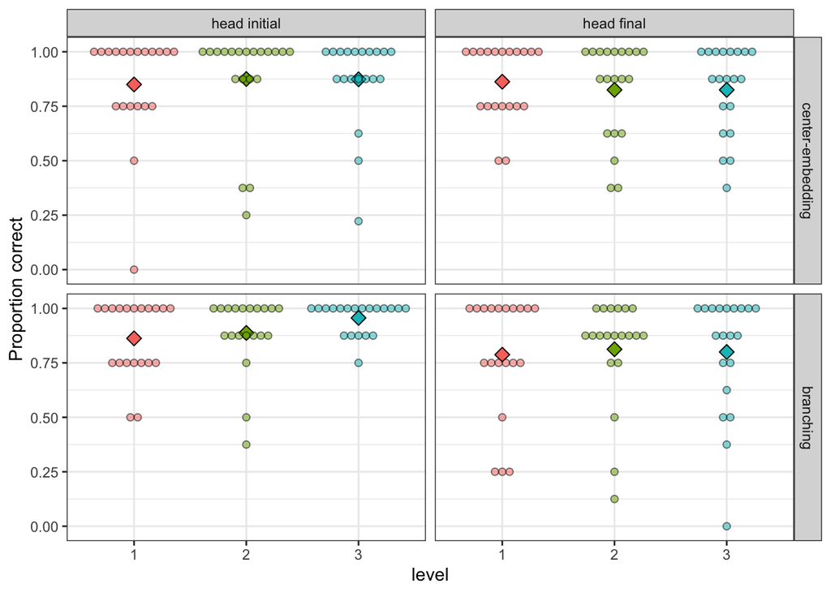

```r
allDataTestingLevel$level <- as.factor(allDataTestingLevel$level)
allDataTestingLevel$conditionHeadN <- as.factor(allDataTestingLevel$conditionHeadN)
allDataTestingLevel$conditionCE <- as.factor(allDataTestingLevel$conditionCE)
allDataTestingLevel$conditionHeadN <- relevel(allDataTestingLevel$conditionHeadN, "head initial", "head final")
allDataTestingLevel$conditionCE <- relevel(allDataTestingLevel$conditionCE, "center-embedding")
library(scales)
colors <- hue_pal()(4)
ggplot(allDataTestingLevel, aes(x= level, y= level_score, fill = level))+
  stat_summary(aes(fill = level,group=1), fun= "mean", geom="point", pch = 23, size = 3) +
  geom_dotplot(binaxis='y',stackdir='center', alpha = .5)+
  facet_grid(conditionCE ~ conditionHeadN)+
  scale_x_discrete(name = "level", labels = c("1", "2", "3"))+
    scale_fill_manual(values = colors[1:3] , labels = c("1", "2", "3"), guide = FALSE)+
  ylab("Proportion correct")+
   theme_bw()
```

Mixed effects model of correct-answer rates on comprehension tests by level.

```r
allDataTestingMerged$level <- as.factor(allDataTestingMerged$level)
allDataTestingMerged$conditionHeadN <- as.factor(allDataTestingMerged$conditionHeadN)
allDataTestingMerged$conditionCE <- as.factor(allDataTestingMerged$conditionCE)
contrasts(allDataTestingMerged$conditionCE) <- contr.sum(2)
contrasts(allDataTestingMerged$conditionHeadN) <- contr.sum(2)
contrasts(allDataTestingMerged$level) <- contr.sdif(3)
testLmerInteract <- glmer(correct ~ level* conditionCE * conditionHeadN + (1 +level|workerId), data = allDataTestingMerged, family = "binomial")
```

## Write-in accuracy

(This stage is simplified a lot in the subsequent experiments, as push-button entry of words was used, rather than free text.)

First create a lexicon for each user, consisting of the correct versions of their nouns and adpositions. This is the language they were trained on.

```r
correctLexicon <- c()
for (worker in unique(allDataWriteMerged$workerId)) {
  workerTrials <- nrow(allDataWriteMerged[allDataWriteMerged$workerId == worker,])
  nouns <- as.character(allDataWriteMerged[allDataWriteMerged$workerId == worker,]$compositionalAnswer[1:4])
  participantCorrects <- paste(c(nouns, "rae", "moy"), collapse = " ")
  correctLexicon <- c(correctLexicon, rep(participantCorrects, workerTrials))
}
allDataWriteMerged <- cbind(allDataWriteMerged, correctLexicon)
allDataWriteMerged$correctLexicon <- as.character(allDataWriteMerged$correctLexicon)
allDataWriteMerged$participantText <- as.character(allDataWriteMerged$participantText)
allDataWriteMerged$participantText[is.na(allDataWriteMerged$participantText)] <- ' '
```

Correct user’s input so that each word becomes the closest (lowest normalized OSA edit distance) word in the lexicon. If words are equidistant from two correct words, pick the first on the list. Unidentifiable words (too far in edit distance from any lexicon word) and a few known English words are notated as X.

```r
correctedAnswers <- c()
for (i in 1:nrow(allDataWriteMerged)) {
  #remove extra spaces
  entry <- gsub("\\s+", " ", str_trim(allDataWriteMerged$participantText[i]))
  split <- strsplit(entry, " ")[[1]]
  correctedWords <- c()
  for (word in split) {
    word = tolower(word)
    dists <- c()
    corrects <- strsplit(allDataWriteMerged$correctLexicon[i], " ")[[1]]
    for (c in corrects) {
      ds <- stringdist(word, c, method = "osa")/max(nchar(word), nchar(c))
      dists <- c(dists, ds)
    }
    closest <- which(dists == min(dists))
    #if equidistant, choose one
    english = c("and", "aside")
    if (min(dists) > .75 || word %in% english) {
      correctedWords <- c(correctedWords, "X")
    } else {
    if (length(closest) > 1) {
      correctedWords <- c(correctedWords, corrects[closest[1]])
    } else {
    correctedWords <- c(correctedWords, corrects[closest])
    }
    }
  }
  cor <- paste(correctedWords, collapse = " ")
  correctedAnswers  <- c(correctedAnswers, cor)
}
allDataWriteMerged <- cbind(allDataWriteMerged, correctedAnswers)
```

Now encode the corrected and compositional columns as initials, and compare by OSA.

```r
encodingCompositional <- c()
encodingCorrected <- c()
for (i in 1:nrow(allDataWriteMerged)) {
  splitP <- strsplit(as.character(allDataWriteMerged$compositionalAnswer[i]), " ")[[1]]
  initialsP <- c()
  for (word in splitP) {
   initialsP <- c(initialsP, substring(word, 1, 1))
    }
  initP <- paste(initialsP, collapse = "")
  encodingCompositional <- c(encodingCompositional, initP)
}
allDataWriteMerged <- cbind(allDataWriteMerged, encodingCompositional)

for (i in 1:nrow(allDataWriteMerged)) {
  splitC <- strsplit(as.character(allDataWriteMerged$correctedAnswers[i]), " ")[[1]]
  initialsC <- c()
  for (word in splitC) {
    initialsC <- c(initialsC, substring(word, 1, 1))
  }
  initC <- paste(initialsC, collapse = "")
  encodingCorrected <- c(encodingCorrected, initC)
}
allDataWriteMerged <- cbind(allDataWriteMerged, encodingCorrected)
normedCorrectness <- c()
for (i in 1:nrow(allDataWriteMerged)) {
  longer = max(
nchar(as.character(allDataWriteMerged$encodingCompositional[i])), nchar(as.character(allDataWriteMerged$encodingCorrected[i])) )
  normedC <- 1- (stringdist(as.character(allDataWriteMerged$encodingCompositional[i]),
                            as.character(allDataWriteMerged$encodingCorrected[i]),
                                      method = "osa")/longer)

  normedCorrectness <- c(normedCorrectness, normedC)
}
allDataWriteMerged <- cbind(allDataWriteMerged, normedCorrectness)
```

# Analyses and graph for resultant score of correctness

```r
allDataWriteMerged$conditionCE <- as.character(allDataWriteMerged$conditionCE)
allDataWriteMerged$conditionCE <- factor(allDataWriteMerged$conditionCE)
allDataWriteMerged$conditionHeadN <- as.character(allDataWriteMerged$conditionHeadN)
allDataWriteMerged$conditionHeadN <- factor(allDataWriteMerged$conditionHeadN)
analyzeWritingMeansN<- function (data_write, lev) {
  data_write_level <- list()
  for (j in 1:length(data_write)) {
    data_write_level[[j]] <- data_write[[j]] %>% group_by(level) %>% summarize(meanC = mean(normedCorrectness))
    data_write_level[[j]]$condition <- rep(data_write[[j]]$condition[1], lev)
    data_write_level[[j]]$conditionCE <- rep(data_write[[j]]$conditionCE[1], lev)
    data_write_level[[j]]$conditionHeadN <- rep(data_write[[j]]$conditionHeadN[1], lev)
    data_write_level[[j]]$user<- rep(data_write[[j]]$workerId[1], lev)
  }

  data_write_levelAll <- rbind()
  for (d in data_write_level) {
    data_write_levelAll <- rbind(data_write_levelAll, d)
  }
  return (data_write_levelAll)
}
writeList <- split(allDataWriteMerged, f = allDataWriteMerged$workerId)
allDataWriteMeansNormed <- analyzeWritingMeansN(writeList, 4)
```

analysis: all arrays

```r
contrasts(allDataWriteMerged$conditionCE) <- contr.sum(2)
contrasts(allDataWriteMerged$conditionHeadN) <- contr.sum(2)
allDataWriteMerged$level <- as.numeric(allDataWriteMerged$level)
writeLmerNormed <- lmer(normedCorrectness ~ as.numeric(level-1)* conditionCE * conditionHeadN + (1 +as.numeric(level-1)|workerId), data = allDataWriteMerged)
```

seen vs. unseen arrays

```r
adwmSeen <- allDataWriteMerged[allDataWriteMerged$seenInTesting == "true",]
adwmSeen$level <- as.factor(adwmSeen$level)
writeListSeen <- split(adwmSeen, f = adwmSeen$workerId)
allDataWriteMeansNormedSeen <- analyzeWritingMeansN(writeListSeen, 3)
adwmUnSeen <- allDataWriteMerged[allDataWriteMerged$seenInTraining == "false",]
adwmUnSeen$level <- as.factor(adwmUnSeen$level)
writeListUnSeen <- split(adwmUnSeen, f = adwmUnSeen$workerId)
allDataWriteMeansNormedUnSeen <- analyzeWritingMeansN(writeListUnSeen, 3)

allDataWriteMerged$seenInTraining <- as.factor(allDataWriteMerged$seenInTraining)
contrasts(allDataWriteMerged$seenInTraining) <- contr.sum(2)
writeLmerNormedSeen <- lmer(normedCorrectness ~ level* conditionCE * conditionHeadN * seenInTraining+ (1 +level|workerId), data = allDataWriteMerged[allDataWriteMerged$level %in% c(1,2),])
```

seen arrays only

```r
allDataTestingMerged$seenInTraining <- as.factor(allDataTestingMerged$seenInTraining)
contrasts(allDataTestingMerged$seenInTraining) <- contr.sum(2)


analyzeWritingMeansNSeen<- function (data_write, lev) {
  data_write_level <- list()
  for (j in 1:length(data_write)) {
    data_write_level[[j]] <- data_write[[j]] %>% group_by(level, seenInTraining) %>% summarize(meanC = mean(normedCorrectness))
    data_write_level[[j]]$condition <- rep(data_write[[j]]$condition[1], lev)
    data_write_level[[j]]$conditionCE <- rep(data_write[[j]]$conditionCE[1], lev)
    data_write_level[[j]]$conditionHeadN <- rep(data_write[[j]]$conditionHeadN[1], lev)
    data_write_level[[j]]$user<- rep(data_write[[j]]$workerId[1], lev)
  }

  data_write_levelAll <- rbind()
  for (d in data_write_level) {
    data_write_levelAll <- rbind(data_write_levelAll, d)
  }
  return (data_write_levelAll)
}
adwmSeenUnseen <- analyzeWritingMeansNSeen(writeList, 6)
```

unseen arrays only

```r
adwmSeenUnseen$level<- factor(as.numeric(adwmSeenUnseen$level+1))
contrasts(adwmSeen$level) <- contr.sdif(3)
contrasts(adwmUnSeen$level) <- contr.sdif(3)

contrasts(adwmSeen$conditionCE) <- contr.sum(2)
contrasts(adwmSeen$conditionHeadN) <- contr.sum(2)
contrasts(adwmUnSeen$conditionCE) <- contr.sum(2)
contrasts(adwmUnSeen$conditionHeadN) <- contr.sum(2)
writeLmerNormedAllSeen <- lmer(normedCorrectness ~ level* conditionCE * conditionHeadN + (1 +level|workerId), data = adwmSeen)
writeLmerNormedAllNoSeen <- lmer(normedCorrectness ~ level* conditionCE * conditionHeadN + (1 +level|workerId), data = adwmUnSeen)
```

#Production graph

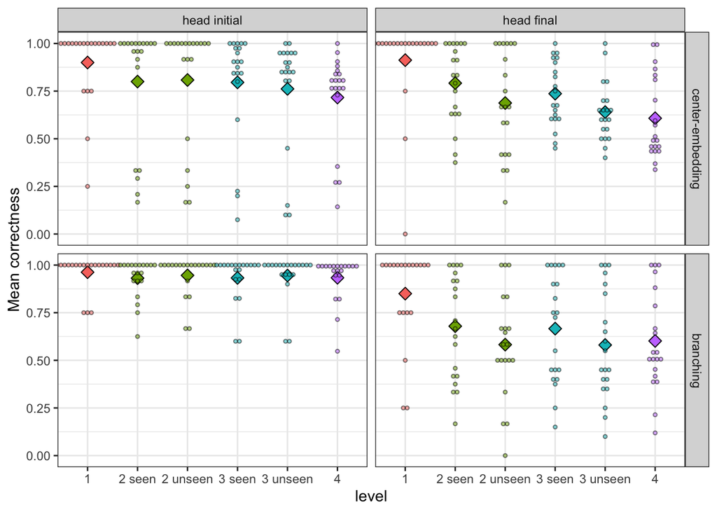

```r
adwmSeenUnseen$conditionCE <- as.factor(adwmSeenUnseen$conditionCE)
adwmSeenUnseen$conditionHeadN <- relevel(adwmSeenUnseen$conditionHeadN, "head initial", "head final")
adwmSeenUnseen$conditionCE <- relevel(adwmSeenUnseen$conditionCE, "center-embedding")
adwmSeenUnseen$group <- as.factor(paste0(adwmSeenUnseen$level, adwmSeenUnseen$seenInTraining))
adwmSeenUnseen$group <- relevel(adwmSeenUnseen$group, "3true")
adwmSeenUnseen$group <- relevel(adwmSeenUnseen$group, "2false")
adwmSeenUnseen$group <- relevel(adwmSeenUnseen$group, "2true")
adwmSeenUnseen$group <- relevel(adwmSeenUnseen$group, "1true")
ggplot(adwmSeenUnseen, aes(x= group, y= meanC, fill = level))+
  stat_summary(aes(fill = level, group=1), fun= "mean", geom="point", pch = 23, size = 3) +
  geom_dotplot(binaxis='y',stackdir='center', alpha = .5, binwidth = .02)+
  facet_grid(conditionCE ~ conditionHeadN )+
  ylab("Mean correctness")+
  theme_bw()+
  theme(legend.position = "none")+
  scale_fill_discrete(name = "level", labels = c("1", "2 seen", "2 unseen", "3 seen","3 unseen", "4"))+
  scale_x_discrete(name = "level", labels = c("1", "2 seen", "2 unseen", "3 seen","3 unseen", "4"))+
    ggsave("/Users/emilydavis/Desktop/iterated/artificial language/pilotLrn1/conditions.png",width=10, height=6)
```

## Coding adpositional meanings

Not all participants interpret the adpositions are they are defined in the compositional language. “Moy” is “to the (viewer’s) left of” and “rae” is “atop,” but some make the opposite interpretations, or are simply not sure. Coding of user interpretations has been done manually.

Prepositions are encoded as follows: A = atop; U = under; E = indef vertical or stacked; N = next to or indef horizontal; R = right of; X = undefined or uninterpretable response.

```r
PH <- c("X", "N", "N", "R", "N", "N", "N", "R", "N", "X",
"N", "N", "N", "N", "N", "X", "N", "N", "N", "N",
"R", "R", "X", "X", "N", "N", "N", "N", "N", "N",
"N", "N", "N", "E", "N", "R", "N", "N", "N", "R",
"X", "N", "X", "N", "N", "N", "N", "N", "X", "X",
"N", "N", "N", "N", "N", "N", "N", "X", "N", "N",
"N", "N", "N", "N", "N", "X", "N", "N", "X", "R",
"N", "N", "N", "N", "X", "N", "X", "N", "N", "U")

PV <- c("X", "A", "E", "U", "A", "E", "E", "U", "A", "X",
"E", "E", "A", "A", "A", "X", "A", "A", "A", "E",
"U", "U", "X", "X", "E", "A", "A", "E", "E", "E",
"A", "E", "E", "N", "A", "U", "E", "A", "E", "U",
"X", "E", "X", "U", "E", "U", "U", "E", "X", "X",
"A", "A", "A", "E", "E", "A", "A", "X", "A", "A",
"A", "A", "U", "E", "E", "X", "E", "A", "X", "A",
"A", "A", "A", "U", "X", "E", "X", "A", "A", "N")
prepList <- cbind(prepList, PH, PV)
prepHorizGloss <-c()
prepVertGloss <- c()
for (w in prepList$workerId) {
  writeCount = nrow(allDataWriteMerged[allDataWriteMerged$workerId == w,])
  prepHorizGloss <- c(prepHorizGloss, rep(as.character(prepList$PH[prepList$workerId== w]), each = writeCount))
  prepVertGloss <- c(prepVertGloss, rep(as.character(prepList$PV[prepList$workerId== w]), each = writeCount))
}
allDataWriteMerged <- cbind(allDataWriteMerged, prepHorizGloss, prepVertGloss)
```

## Creating write-in file

Saving initials of given nouns for further analysis. Nouns will be used to create strings in all possible grammars that users may be using (in the python program described below), to which their corrected, abbreviated input can be compared.

```r
consonants <- c()
for (n in 1:nrow(allDataWriteMerged)) {
consonants <- c(consonants, paste0(sapply(strsplit(as.character(allDataWriteMerged$correctLexicon[n]), " "), function(x) {substring(x, 1,1)})[0:4], collapse = ""))}
allDataWriteMerged <- cbind(allDataWriteMerged, consonants)
write.csv(allDataWriteMerged, '/Users/emilydavis/Desktop/iterated/artificial language/pilotLrn1/allDataWritePilotLrn1.csv')
write.csv(prepList, '/Users/emilydavis/Desktop/iterated/artificial language/pilotLrn1/prepListPilotLrn1.csv')
```

The resulting CSV is then fed through the python file “array to caption syntax orders”

Output models to HTML

```r
library(sjPlot)
a<- as.data.frame(coefficients(summary(testLmerInteract)))
rownames(a) <-gsub("Intercept", "level 1/branching/head-initial", rownames(a))
rownames(a) <-gsub("as.numeric\\(level - 1\\)", "level 3", rownames(a))
rownames(a) <-gsub("conditionCE1", "center-embedded", rownames(a))
rownames(a) <-gsub("conditionHeadN1", "head-final", rownames(a))
rownames(a) <-gsub(":", "/", rownames(a))

b<- as.data.frame(coefficients(summary(writeLmerNormed)))
rownames(b) <-gsub("Intercept", "level 1/branching/head-initial", rownames(b))
rownames(b) <-gsub("as.numeric\\(level - 1\\)", "level", rownames(b))
rownames(b) <-gsub("conditionCE1", "center-embedding", rownames(b))
rownames(b) <-gsub("conditionHeadN1", "head-final", rownames(b))
rownames(b) <-gsub(":", "/", rownames(b))

c<- as.data.frame(coefficients(summary(writeLmerNormedSeen)))
rownames(c) <-gsub("Intercept", "level 2/branching/head-initial/unseen", rownames(c))
rownames(c) <-gsub("level", "level 3", rownames(c))
rownames(c) <-gsub("conditionCE1", "center-embedding", rownames(c))
rownames(c) <-gsub("conditionHeadN1", "head-final", rownames(c))
rownames(c) <-gsub("seenInTraining1", "unseen", rownames(c))
rownames(c) <-gsub(":", "/", rownames(c))

d<- as.data.frame(coefficients(summary(writeLmerNormedAllSeen)))
rownames(d) <-gsub("Intercept", "level 1/branching/head-initial", rownames(d))
rownames(d) <-gsub("as.numeric\\(level - 1\\)", "level", rownames(d))
rownames(d) <-gsub("conditionCE1", "center-embedding", rownames(d))
rownames(d) <-gsub("conditionHeadN1", "head-final", rownames(d))
rownames(d) <-gsub(":", "/", rownames(d))

e<- as.data.frame(coefficients(summary(writeLmerNormedAllNoSeen)))
rownames(e) <-gsub("Intercept", "level 2/branching/head-initial", rownames(e))
rownames(e) <-gsub("as.numeric\\(level - 1\\)", "level", rownames(e))
rownames(e) <-gsub("conditionCE1", "center-embedding", rownames(e))
rownames(e) <-gsub("conditionHeadN1", "head-final", rownames(e))
rownames(e) <-gsub(":", "/", rownames(e))
rownames(e) <-gsub("3-2", "4-3", rownames(e))
rownames(e) <-gsub("2-1", "3-2", rownames(e))

library(sjmisc)
allModels <- list(a, b,c, d, e)
for (i in 1:length(allModels)) {
  allModels[[i]] <- round_num(allModels[[i]], 3)
allModels[[i]][,ncol(allModels[[i]])][allModels[[i]][,ncol(allModels[[i]])] == 0] <- "< .001"
}
tab_dfs(allModels, titles = c("Comprehension task", "Production task", "Seen vs. unseen arrays", "Production task: seen only", "Production task: novel only"), file = '/Users/emilydavis/Desktop/iterated/artificial language/pilotLrn1/a.html')
```

Comprehension task

| Row | Estimate | Std. Error | z value | Pr(>\|z\|) |
| --- | --- | --- | --- | --- |
| (level 1/branching/head-initial) | 2.406 | 0.2 | 12.021 | < .001 |
| level2-1 | 0.526 | 0.315 | 1.671 | 0.095 |
| level3-2 | 0.176 | 0.297 | 0.595 | 0.552 |
| center-embedded | 0.011 | 0.185 | 0.057 | 0.955 |
| head-final | -0.392 | 0.185 | -2.115 | 0.034 |
| level2-1/center-embedded | 0.073 | 0.238 | 0.305 | 0.76 |
| level3-2/center-embedded | 0.288 | 0.203 | 1.421 | 0.155 |
| level2-1/head-final | -0.234 | 0.239 | -0.98 | 0.327 |
| level3-2/head-final | -0.303 | 0.207 | -1.46 | 0.144 |
| center-embedded/head-final | -0.161 | 0.185 | -0.872 | 0.383 |
| level2-1/center-embedded/head-final | 0.145 | 0.237 | 0.613 | 0.54 |
| level3-2/center-embedded/head-final | -0.333 | 0.202 | -1.65 | 0.099 |

Production task

| Row | Estimate | Std. Error | df | t value | Pr(>\|t\|) |
| --- | --- | --- | --- | --- | --- |
| (level 1/branching/head-initial) | 0.811 | 0.023 | 76.003 | 35.8 | < .001 |
| level | -0.05 | 0.006 | 76.003 | -7.816 | < .001 |
| center-embedding | 0.008 | 0.023 | 76.003 | 0.363 | 0.718 |
| head-final | -0.072 | 0.023 | 76.003 | -3.17 | 0.002 |
| level/center-embedding | 0.02 | 0.006 | 76.003 | 3.045 | 0.003 |
| level/head-final | -0.022 | 0.006 | 76.003 | -3.344 | 0.001 |
| center-embedding/head-final | -0.052 | 0.023 | 76.003 | -2.292 | 0.025 |
| level/center-embedding/head-final | -0.003 | 0.006 | 76.003 | -0.502 | 0.617 |

Seen vs. unseen arrays

| Row | Estimate | Std. Error | df | t value | Pr(>\|t\|) |
| --- | --- | --- | --- | --- | --- |
| (level 3 2/branching/head-initial/unseen) | 0.799 | 0.033 | 79.052 | 24.122 | < .001 |
| level 3 | -0.021 | 0.013 | 84.976 | -1.67 | 0.099 |
| center-embedding | -0.011 | 0.033 | 79.052 | -0.33 | 0.742 |
| head-final | -0.085 | 0.033 | 79.052 | -2.559 | 0.012 |
| unseen | -0.019 | 0.014 | 1746.513 | -1.384 | 0.166 |
| level 3/center-embedding | 0.017 | 0.013 | 84.976 | 1.371 | 0.174 |
| level 3/head-final | -0.008 | 0.013 | 84.976 | -0.657 | 0.513 |
| center-embedding/head-final | -0.065 | 0.033 | 79.052 | -1.976 | 0.052 |
| level 3/unseen | -0.003 | 0.009 | 1746.783 | -0.364 | 0.716 |
| center-embedding/unseen | -0.004 | 0.014 | 1746.513 | -0.278 | 0.781 |
| head-final/unseen | -0.036 | 0.014 | 1746.513 | -2.598 | 0.009 |
| level 3/center-embedding/head-final | 0.005 | 0.013 | 84.976 | 0.369 | 0.713 |
| level 3/center-embedding/unseen | 0.006 | 0.009 | 1746.783 | 0.635 | 0.525 |
| level 3/head-final/unseen | 0.008 | 0.009 | 1746.783 | 0.897 | 0.37 |
| center-embedding/head-final/unseen | 0.005 | 0.014 | 1746.513 | 0.35 | 0.726 |
| level 3/center-embedding/head-final/unseen | -0.005 | 0.009 | 1746.783 | -0.537 | 0.591 |

Production task: seen only

| Row | Estimate | Std. Error | df | t value | Pr(>\|t\|) |
| --- | --- | --- | --- | --- | --- |
| (level 1/branching/head-initial) | 0.83 | 0.023 | 75.926 | 36.863 | < .001 |
| level2-1 | -0.106 | 0.024 | 76.024 | -4.485 | < .001 |
| level3-2 | -0.018 | 0.013 | 76.37 | -1.347 | 0.182 |
| center-embedding | 0.007 | 0.023 | 75.926 | 0.311 | 0.757 |
| head-final | -0.057 | 0.023 | 75.926 | -2.536 | 0.013 |
| level2-1/center-embedding | 0.004 | 0.024 | 76.024 | 0.185 | 0.854 |
| level3-2/center-embedding | 0.012 | 0.013 | 76.37 | 0.921 | 0.36 |
| level2-1/head-final | -0.04 | 0.024 | 76.024 | -1.708 | 0.092 |
| level3-2/head-final | -0.016 | 0.013 | 76.37 | -1.167 | 0.247 |
| center-embedding/head-final | -0.048 | 0.023 | 75.926 | -2.138 | 0.036 |
| level2-1/center-embedding/head-final | -0.03 | 0.024 | 76.024 | -1.269 | 0.208 |
| level3-2/center-embedding/head-final | 0.009 | 0.013 | 76.37 | 0.707 | 0.482 |

Production task: novel only

| Row | Estimate | Std. Error | df | t value | Pr(>\|t\|) |
| --- | --- | --- | --- | --- | --- |
| (level 2/branching/head-initial) | 0.734 | 0.025 | 75.999 | 29.887 | < .001 |
| level3-2 | -0.024 | 0.019 | 76.102 | -1.293 | 0.2 |
| level4-3 | -0.017 | 0.013 | 76.196 | -1.31 | 0.194 |
| center-embedding | 0.031 | 0.025 | 75.999 | 1.245 | 0.217 |
| head-final | -0.118 | 0.025 | 75.999 | -4.787 | < .001 |
| level3-2/center-embedding | 0.023 | 0.019 | 76.102 | 1.221 | 0.226 |
| level4-3/center-embedding | 0.022 | 0.013 | 76.196 | 1.676 | 0.098 |
| level3-2/head-final | 0 | 0.019 | 76.102 | -0.025 | 0.98 |
| level4-3/head-final | 0.011 | 0.013 | 76.196 | 0.88 | 0.382 |
| center-embedding/head-final | -0.059 | 0.025 | 75.999 | -2.404 | 0.019 |
| level3-2/center-embedding/head-final | 0 | 0.019 | 76.102 | -0.003 | 0.997 |
| level4-3/center-embedding/head-final | 0.005 | 0.013 | 76.196 | 0.385 | 0.701 |